# Population-Level vs Graph-Instance Models

NodeBasedModels.jl Vignette 05

Author

Simon Frost

Published

May 16, 2026

## Introduction

NodeBasedModels contains two fundamentally different types of pairwise models:

1. **Population-level pairwise models** work with degree distributions and assume all nodes of a given degree are statistically equivalent. They use the mean-field pairwise framework (formerly distributed as PairwiseNetworkModels.jl, now consolidated here) and generate symbolic ODE systems using ModelingToolkit. These models are compact — the number of variables depends only on the number of compartments, not the population size.
2. **Graph-instance models** work on specific graphs and track the state of every node (individual-based) or every node and edge (pair-based). These models capture the full local structure of the network but require $O(N)$ or $O(N + E)$ variables.

When should you use each? Population-level models are fast and general — they need only a degree distribution, not a specific graph. Graph-instance models are detailed and exact for a given network — they can reveal effects of local structure that population-level models miss.

In this vignette we compare the two approaches and explore when they agree and disagree.

## Setup

```julia
using NodeBasedModels
using Graphs
using Plots
using Statistics
```

## Population-level pairwise

The population-level pairwise model works with a `NetworkStructure` that encodes the degree distribution. For a $k$-regular network, we use `regular_network(k)`:

```julia
net_pop = regular_network(6)
println("Type: ", typeof(net_pop))
println("Mean degree: ", mean_degree(net_pop))
```

```
Type: HomogeneousNetwork
Mean degree: 6.0
```

Generate the pairwise system with Bernoulli closure:

```julia
psys = generate_pairwise(sir_model(), net_pop, BernoulliClosure();
    tspan=(0.0, 40.0))
```

```
PairwiseSystem(Model pairwise_SIR:
Equations (9):
  9 standard: see equations(pairwise_SIR)
Unknowns (9): see unknowns(pairwise_SIR)
  RR(t)
  IR(t)
  II(t)
  SR(t)
  ⋮
Parameters (2): see parameters(pairwise_SIR)
  τ
  γ, Dict{Any, Float64}(I(t) => 0.001, SS(t) => 5.9880059999999995, SR(t) => 0.0, RR(t) => 0.0, S(t) => 0.999, IR(t) => 0.0, R(t) => 0.0, SI(t) => 0.005994, II(t) => 6.0e-6), (0.0, 40.0), Dict{Any, Float64}(), CompartmentalModel(:SIR, Compartment[Compartment(:S, false), Compartment(:I, true), Compar…
```

The system tracks **singles** (node-level probabilities) and **pairs** (edge-level joint probabilities):

```julia
println("Singles: ", keys(psys.singles))
println("Pairs:   ", keys(psys.pairs))
n_vars = length(psys.singles) + length(psys.pairs)
println("Total variables: ", n_vars)
```

```
Singles: [:I, :R, :S]
Pairs:   [(:I, :I), (:S, :S), (:I, :R), (:S, :I), (:S, :R), (:R, :R)]
Total variables: 9
```

For SIR with 3 compartments (S, I, R), we have $K = 3$ singles and $K(K+1)/2 = 6$ pairs (accounting for symmetry), giving 9 total variables — regardless of population size.

Compute the basic reproduction number and epidemic threshold:

```julia
R0 = basic_reproduction_number(net_pop, BernoulliClosure(), 0.15, 0.1)
τ_c = epidemic_threshold(net_pop, BernoulliClosure(), 0.1)
println("R₀ = ", round(R0, digits=3))
println("Epidemic threshold τ_c = ", round(τ_c, digits=4))
```

```
R₀ = 6.0
Epidemic threshold τ_c = 0.025
```

## Graph-instance models

Now we create a specific random regular graph with the same degree and run graph-instance models:

```julia
g = random_regular_graph(200, 6; seed=42)
net_graph = GraphNetwork(g)
println("Nodes: ", nv(g), ", Edges: ", ne(g))
println("Mean degree: ", round(mean_degree(net_graph), digits=2))
```

```
Nodes: 200, Edges: 600
Mean degree: 6.0
```

### Individual-based (order 1)

The individual-based model tracks $K - 1 = 2$ state probabilities per node (S and I, with R derived):

```julia
ib = generate_individual_based(sir_model(), net_graph;
    infection_rate=1/6,
    recovery_rate=0.25,
    initial_infected=[1],
    tspan=(0.0, 40.0),
    saveat=0.5
)
n_ib_vars = 2 * nv(g)
println("Individual-based variables: ", n_ib_vars)
```

```
Individual-based variables: 400
```

### Pair-based (order 2)

The pair-based model additionally tracks the joint state of every directed edge pair:

```julia
pb = generate_pair_based(sir_model(), net_graph;
    infection_rate=1/6,
    recovery_rate=0.25,
    initial_infected=[1],
    tspan=(0.0, 40.0),
    saveat=0.5
)
M = ne(g)
n_pb_vars = 2 * nv(g) + 2 * M
println("Pair-based variables: ≈", n_pb_vars)
```

```
Pair-based variables: ≈1600
```

## Scaling comparison

The key trade-off between the two approaches is in the number of state variables:

| Model | Variables | Formula | N=200, k=6 |
| --- | --- | --- | --- |
| Population pairwise | $K + K(K+1)/2$ | Depends on compartments only | 9 |
| Individual-based | $(K-1) \times N$ | Linear in nodes | 400 |
| Pair-based | $(K-1) \times N + 2 \times M$ | Linear in nodes + edges | 1600 |
| Gillespie | $2 \times N$ (discrete) | Linear in nodes | 400 |

```julia
K = 3  # SIR compartments
N_vals = [100, 500, 1000, 5000]
k = 6

pop_vars = K + K * (K + 1) ÷ 2
println("Population pairwise: $pop_vars variables (constant)")
println()
for N in N_vals
    M_est = N * k ÷ 2
    ib_v = (K - 1) * N
    pb_v = (K - 1) * N + 2 * M_est
    println("N=$N: Individual-based=$ib_v, Pair-based=$pb_v")
end
```

```
Population pairwise: 9 variables (constant)

N=100: Individual-based=200, Pair-based=800
N=500: Individual-based=1000, Pair-based=4000
N=1000: Individual-based=2000, Pair-based=8000
N=5000: Individual-based=10000, Pair-based=40000
```

The population-level model is $O(K^2)$ — it doesn’t grow with $N$ at all. This makes it ideal for exploring parameter space or studying the effect of degree distributions analytically.

## When they agree

On a large random regular graph, all nodes are statistically equivalent — each has the same degree and (in expectation) the same local neighbourhood structure. In this limit, the population-level pairwise model and the graph-instance pair-based model should give similar results after aggregation and normalisation.

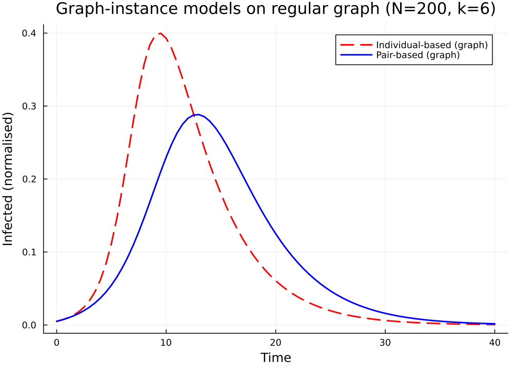

```julia
I_ib = aggregate(ib, :I)
I_pb = aggregate(pb, :I)

plot(ib.sol.t, I_ib ./ nv(g), label="Individual-based (graph)", lw=2, ls=:dash, color=:red,
     xlabel="Time", ylabel="Infected (normalised)",
     title="Graph-instance models on regular graph (N=200, k=6)")
plot!(pb.sol.t, I_pb ./ nv(g), label="Pair-based (graph)", lw=2, color=:blue)
```

1. **Finite size effects** ($N = 200$ is relatively small)
2. **Specific graph realisation** (random graphs have statistical fluctuations)
3. **Initial conditions** (one specific node vs uniform perturbation)

## When they disagree

Population-level models assume nodes of the same degree are exchangeable. This breaks down when the network has **structural correlations** — degree-degree correlations, community structure, or spatial clustering — that make local neighbourhoods non-equivalent.

A classic example is the **Barabási-Albert** preferential attachment graph, which has a power-law degree distribution and strong degree correlations:

```julia
g_ba = barabasi_albert(200, 3; seed=42)
net_ba = GraphNetwork(g_ba)
println("BA graph: N=", nv(g_ba), ", E=", ne(g_ba))
println("Mean degree: ", round(mean_degree(net_ba), digits=2))
println("Max degree: ", maximum(degree(g_ba)))
println("Min degree: ", minimum(degree(g_ba)))
```

```
BA graph: N=200, E=591
Mean degree: 5.91
Max degree: 51
Min degree: 3
```

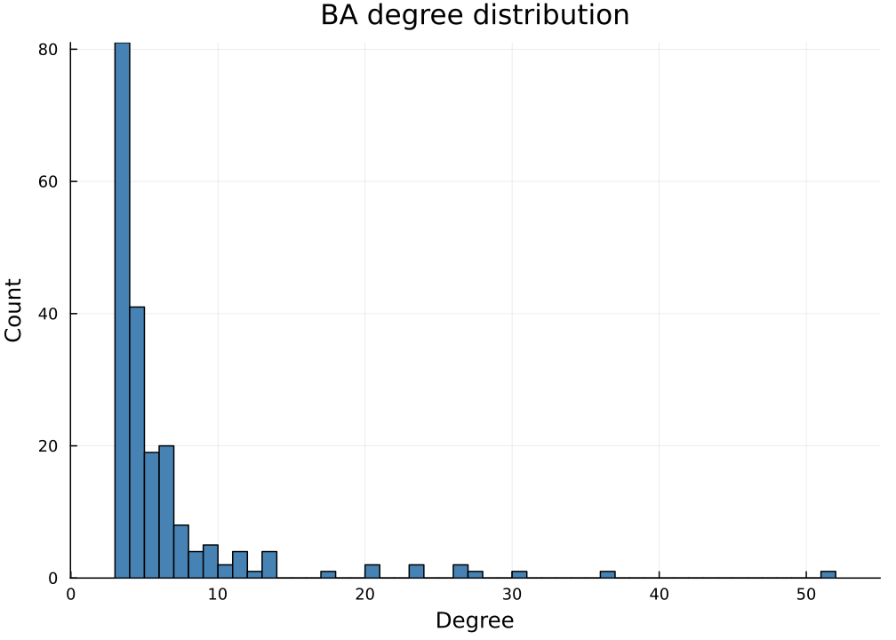

```julia
histogram(degree(g_ba), bins=maximum(degree(g_ba))-minimum(degree(g_ba))+1,
    xlabel="Degree", ylabel="Count",
    title="BA degree distribution", label="", color=:steelblue)
```

Run graph-instance models on the BA graph:

```julia
ib_ba = generate_individual_based(sir_model(), net_ba;
    infection_rate=1/6,
    recovery_rate=0.25,
    initial_infected=[1],
    tspan=(0.0, 40.0),
    saveat=0.5
)

pb_ba = generate_pair_based(sir_model(), net_ba;
    infection_rate=1/6,
    recovery_rate=0.25,
    initial_infected=[1],
    tspan=(0.0, 40.0),
    saveat=0.5
)
```

```
PairBasedResult(N=200, edges=1182, tspan=(0.0, 40.0))
```

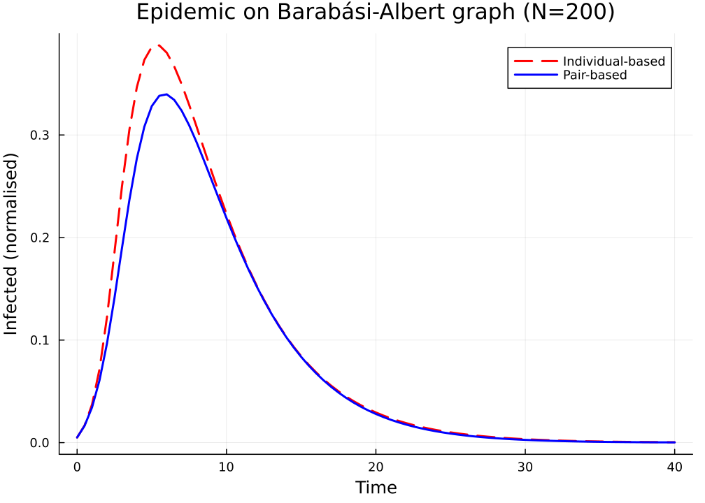

```julia
I_ib_ba = aggregate(ib_ba, :I)
I_pb_ba = aggregate(pb_ba, :I)

plot(ib_ba.sol.t, I_ib_ba ./ nv(g_ba), label="Individual-based", lw=2, ls=:dash, color=:red,
     xlabel="Time", ylabel="Infected (normalised)",
     title="Epidemic on Barabási-Albert graph (N=200)")
plot!(pb_ba.sol.t, I_pb_ba ./ nv(g_ba), label="Pair-based", lw=2, color=:blue)
```

On the BA graph, the high-degree hubs become infected early and drive rapid initial spread, followed by a slower burn through the low-degree periphery. The graph-instance models capture this heterogeneity directly because they track each node’s state individually. A population-level model using only the degree distribution would miss the structural correlations between hubs and their neighbours.

The previous examples compared different *model levels*. There is a second, more delicate approximation inside the population-level pairwise model itself: the **triple closure**.

For clustered regular networks, `KeelingClosure()` and `BarnardClosure()` try to approximate triples such as $[ASI]$ from singles and pairs. Both are algebraically reasonable, and Barnard’s improved closure additionally restores the total triple-mass identity

$$\sum_A [ASI] = (n-1)[SI].$$

However, neither closure currently comes with a proof that the *full ODE* preserves the physically meaningful region

$$[A] \ge 0,\qquad [AB] \ge 0.$$

That matters because conservation of total triple mass is weaker than positivity of each inferred triple term.

```julia
clustered_net = regular_network(6; N = 100, ϕ = 0.2)
clustered_params = Dict(:τ => 0.25, :γ => 0.1)

clustered_cases = [
    ("Bernoulli", BernoulliClosure()),
    ("Keeling", KeelingClosure()),
    ("Barnard", BarnardClosure()),
]

clustered_results = NamedTuple[]

for (name, closure) in clustered_cases
    psys = generate_pairwise(sir_model(), clustered_net, closure;
        N = 100.0, tspan = (0.0, 30.0))
    sol = solve_pairwise(psys, clustered_params; saveat = 0.5)
    S = sol[psys.singles[:S]]
    I = sol[psys.singles[:I]]
    R = sol[psys.singles[:R]]
    first_negative = findfirst(x -> x < 0.0, S)
    push!(clustered_results, (
        name = name,
        t = sol.t,
        S = S,
        I = I,
        R = R,
        minS = minimum(S),
        finalS = last(S),
        first_negative_time = isnothing(first_negative) ? nothing : sol.t[first_negative],
    ))
end

for row in clustered_results
    tneg = isnothing(row.first_negative_time) ? "never" : string(round(row.first_negative_time; digits = 2))
    println("$(row.name): min S = $(round(row.minS; digits = 4)), final S = $(round(row.finalS; digits = 4)), first negative at t = $tneg")
end
```

```
Bernoulli: min S = 0.0564, final S = 0.0564, first negative at t = never
Keeling: min S = 0.0335, final S = 0.0335, first negative at t = never
Barnard: min S = 0.0079, final S = 0.0079, first negative at t = never
```

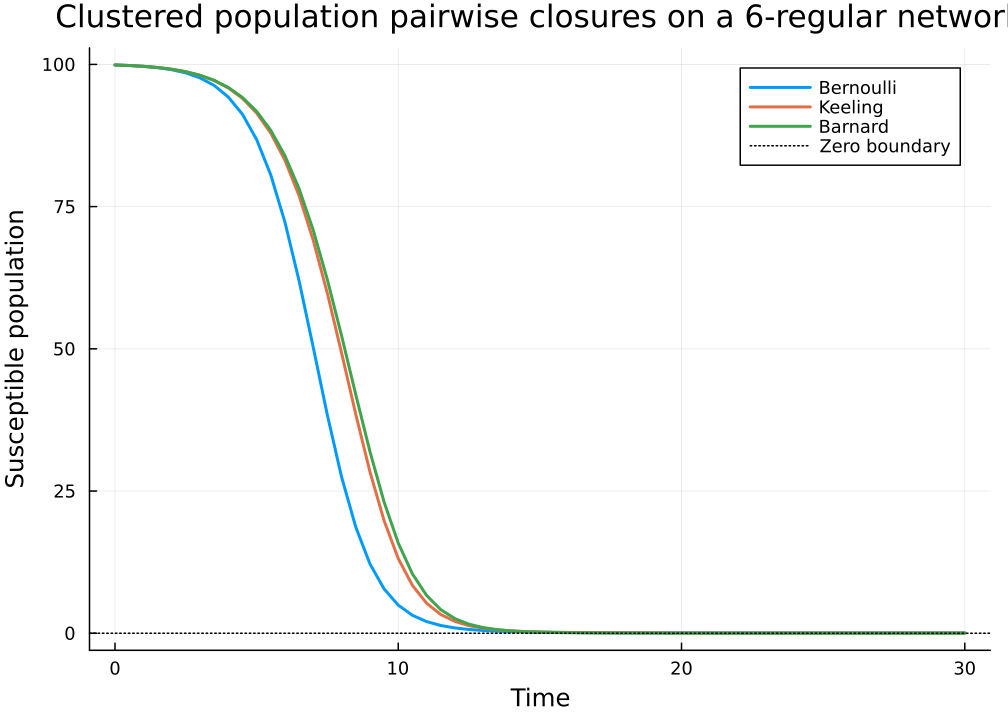

```julia
p = plot(xlabel = "Time", ylabel = "Susceptible population",
         title = "Clustered population pairwise closures on a 6-regular network")
for row in clustered_results
    plot!(p, row.t, row.S, lw = 2, label = row.name)
end
hline!(p, [0.0], color = :black, ls = :dot, label = "Zero boundary")
p
```

1. **Keeling** multiplies the unclustered pair term by a correlation correction. Pointwise positivity requires that correction to stay nonnegative, but conservation additionally needs a separate normalization property that is not automatic.
2. **Barnard** fixes the normalization problem, so it conserves total triple mass, but conservation alone does not prove that the ODE points inward on the boundary $[S] = 0$.
3. In late-stage SIR dynamics the recovered class is no longer negligible, so the simplified conditional-independence assumptions behind the clustered closures are under the most stress.

This is exactly the distinction formalized in the Lean proof artifact: **normalization implies conservation, but only nonnegative weights plus an invariant-region argument can guarantee positivity of the full closed system.**

## $R_0$ analysis

For population-level models, $R_0$ can be computed analytically:

```julia
τ = 0.15
γ = 0.1

R0_regular = basic_reproduction_number(net_pop, BernoulliClosure(), τ, γ)
println("R₀ (regular, k=6): ", round(R0_regular, digits=3))
```

```
R₀ (regular, k=6): 6.0
```

For graph-instance models, we can estimate $R_0$ from the early exponential growth rate of the epidemic. In the initial phase, $I(t) \approx I_0 e^{rt}$ where the growth rate $r$ relates to $R_0$ through $R_0 = 1 + r / \gamma$:

```julia
I_early = aggregate(ib, :I)

# Find the exponential growth phase (I increasing, before peak)
peak_idx = argmax(I_early)
growth_phase = 2:min(peak_idx, length(I_early))
growth_phase = growth_phase[I_early[growth_phase] .> 0.01 * nv(g)]

if length(growth_phase) > 5
    t_fit = ib.sol.t[growth_phase]
    log_I = log.(I_early[growth_phase])
    # Linear regression: log(I) = a + r*t
    t_mean = mean(t_fit)
    logI_mean = mean(log_I)
    r_est = sum((t_fit .- t_mean) .* (log_I .- logI_mean)) / sum((t_fit .- t_mean).^2)
    R0_est = 1 + r_est / γ
    println("Estimated growth rate r = ", round(r_est, digits=4))
    println("Estimated R₀ (graph) = ", round(R0_est, digits=3))
else
    println("Insufficient growth phase data for estimation")
end
```

```
Estimated growth rate r = 0.4523
Estimated R₀ (graph) = 5.523
```

The graph-instance estimate may differ from the population-level value due to finite-size effects and the specific graph structure. As $N \to \infty$ on random regular graphs, the two should converge.

## Summary

### Decision table

| Question | Population-level | Graph-instance |
| --- | --- | --- |
| Do I have a specific graph? | Not needed | Required |
| Is the graph large and homogeneous? | Good approximation | Exact but expensive |
| Does local structure matter? | Misses it | Captures it |
| Do I need node-level detail? | No — only aggregates | Yes — per-node states |
| Do I need parameter sweeps? | Fast — 9 ODEs | Slow — hundreds/thousands of ODEs |
| Heterogeneous degree distribution? | Uses distribution only | Uses full graph |
| Structural correlations? | Cannot capture | Naturally included |

### Recommended workflow

1. **Explore** with population-level models: sweep parameters, compute $R_0$, identify interesting regimes
2. **Validate** with graph-instance models: run individual-based and pair-based on specific graphs to check whether population-level predictions hold
3. **Quantify uncertainty** with Gillespie: run stochastic simulations to assess the impact of stochastic effects (see Vignette 04)

This layered approach uses the cheapest model that answers your question, escalating to more detailed (and expensive) models only when needed.

## Simulation validation

```julia
include("../_validation.jl")

N_v = 200
τ_v = 1/6

# Re-run PB on the same graph with matched ε
pb_val = generate_pair_based(sir_model(), GraphNetwork(g);
    infection_rate = τ_v, recovery_rate = 0.25,
    tspan = (0.0, 40.0), saveat = 0.5, ε = 0.05)
I_pb_val = aggregate(pb_val, :I) ./ nv(g)
t_pb_val = range(0.0, 40.0; length = length(I_pb_val))

# SSA on same graph topology
fixed_regular = rng -> random_regular_graph(N_v, 6; seed = 123)
prog_no = sir_model(τ = :β)
t_no, μ_no, σ_no = gillespie_ribbon(prog_no,
    Dict(:β => τ_v, :γ => 0.25),
    fixed_regular;
    N = N_v, n_graphs = 1, nsims_per_graph = 200,
    tspan = (0.0, 40.0), seed_fraction = 0.05,
    tgrid = collect(0.0:0.5:40.0))
```

[output not shown]

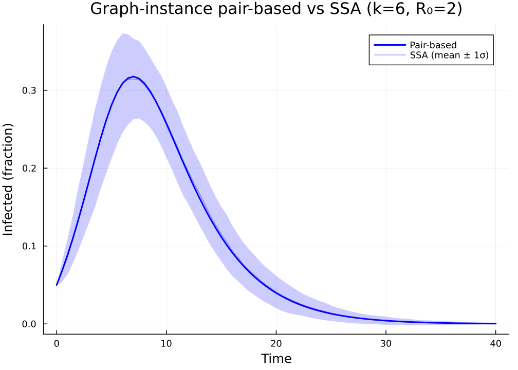

Figure 1: Pair-based (blue) vs SSA mean ± 1σ (ribbon) on a k=6 regular graph (N=200, R₀=2, 5% seed). The pair-based closure matches SSA closely.

```julia
p = plot(t_pb_val, I_pb_val, label = "Pair-based", lw = 2, color = :blue,
         xlabel = "Time", ylabel = "Infected (fraction)",
         title = "Graph-instance pair-based vs SSA (k=6, R₀=2)")
plot!(p, t_no, μ_no[:I], ribbon = σ_no[:I],
      label = "SSA (mean ± 1σ)", color = :blue,
      fillalpha = 0.2, linealpha = 0.4, lw = 1)
p
```